# Adaptations to sea level change and the transition to agriculture in tropical monsoonal Peninsula Thailand

Ben Marwick

Cyler Conrad

Rasmi Shoocongdej

Cholawit Thongcharoenchaikit

Hannah Van Vlack

Seungki Kwak

2016-01-14

```r
library(knitr)
opts_chunk$set(fig.path='../figures/',
                      echo=FALSE, warning=FALSE, message=FALSE, cache=TRUE)
library(captioner)
tab_n <- captioner(prefix = "Table")
fig_n <- captioner(prefix = "Figure")

library(dplyr)
```

## Introduction

One of the hottest disputes in discussions of the Late Pleistocene and Holocene archaeology of mainland Southeast Asia is the nature of the transition from forager economies to agricultural economies. As a key milestone in complex human-environment interactions, the debate has many dimensions. At one extreme of the debate is the claim that agricultural technologies and cultures appeared in Southeast Asia as a result of influence from north Asia, via the lower Yangtze River and the Yellow River. At the other extreme is the claim is that agriculture emerged from a locally contingent trajectory of changes in human-environment relationships (cf. Hunt and Rabett 2014). While the cultivation of rice and the domestication of pigs and cattle took place in the Yangtze Valley earlier than elsewhere in mainland SEA (Higham et al. 2011; Chi and Hung 2010), the influence of local contingencies remains poorly understood. One of the enduring challenges is that a critical period of time for this transition – the Late Pleistocene through to the middle Holocene – is sparsely represented in the archaeological record. We have a rich and well-documented record for the later Holocene when people were living more sendentary lifestyles, for example at Khok Phanom Di in Thailand and Man Bac in Vietnam. And we have many cave and rockshelter sites representing Pleistocene forager lifestyles, such as Tham Lod in Thailand and Xom Trai in Vietnam.

However, middle Holocene (roughly uncal. 6000–3500 BP), the archaeological record in mainland SEA is particularly sparse. This major gap in archaeological evidence for the region has been called ‘the missing millennia’ (White and Bouasisengpaseuth 2008:39). It is an important period because major changes occured during this time. Ceramics appeared in many parts of Southeast Asia; domesticated plants such as millet and rice appeared; stone artefact technologies transitioning from mostly flaked to mostly ground stone artefacts; settlements expanded from primarily karstic upland and estuarine landscapes during the early Holocene to include inland alluvial lowland villages by the late Holocene (White 2011).

In this paper we present evidence of human activity from coastal Thailand that spans ‘the missing millennia’. Khao Toh Chong rockshelter is significant because it has a rich faunal record spanning the middle Holocene, and is located in an area with a well-documented sea level curve. This provides a unique opportunity to investigate locally contingent factors such as sea level changes on human subsistence behaviours at a critical time in the period of the transition from forager economies to agricultural economies. We report on a geoarchaeological analysis of the site to provide a local environmental context to the human occupation, as well as helping to understand site formation processes and artefact taphonomy.

## Background

The Guangxi Province of southern China has extensive evidence of a forager economy with a semi-sedentary lifestyle during c. 7-4 k BP (Higham 2013). Cave occupation continues until 6000 BC in Xianrendong and 5000–4000 BC in Zengpiyan, and more than 30 open sites containing shell middens have been found on the terraces of the Zuojiang, Youjiang and Yongjiang rivers near Nanning, in southern Guangxi (Fu 2002; Chi and Hung 2012). Occupation of these sites, characterised by the largest, Dingsishan, spans 7000-3500 BC. The sites include pottery manufacturing workshops, cemetaries and large quantities of aquatic and terrestrial animal bones, indicating that fishing and hunting were important activities (no cultivars have been recovered). The archaeology of this region gives the impression of a continuous sequence of human occupation. We see gradual, overlapping adaptations resulting in changes in landscape use, the appearance of pottery and use of cemetaries, and at a much later date, an agricultural economy. The pottery and burial practices of the Dingsishan shell middens is identical to those found at the Da But sites of northern Vietnam, such as Da But, Con Co Ngua, Ban Ban Thuy, Lang Cong and Go Trung. These sites were occupied by complex hunter-gatherer populations during 5500–2000 BC (Viet 2007). Polished axes, pestles and mortars suggest cultivation, but clear evidence of food production only appears around 1500-1800 BC at sites such as Man Bac with domesticated pig remains (Sawada et al., 2011).

While this gives a picture of continuity between complex hunter-gatherers and agriculturalists in southern China and northern Vietnam, elsewhere in mainland Southeast Asia continuity is harder to see. For example, there is a gap between cave occupation and open site occupation in Thailand. At Lang Rongrien rockshelter on peninsular Thailand, the most recent dated occupation is about 8000 BP, followed by undated and highly disturbed deposits containing burials and pottery (Anderson 1990:20). Similarly, in northern Thailand rockshelter occupation at Tham Lod and Ban Rai becomes discontinuous at around 8000 BP (Marwick and Gagan 2011; Schoocongdej, 2006). At Laang Spean rockshelter in Cambodia, the most recent occupation in 5000 BP, followed by later disturbance of the stratigraphy (Sophady et al. 2015; Forestier 2015). The general pattern seems to be that cave and rockshelter sites switch from being occasional habitation sites to burial sites in the middle Holocene (Anderson 1997). A key challenge here is that the burials disturb the stratigraphy, making it difficult to assess continuity between forager occupation and later activity. At open sites, the record starts at around 2000 BC (i.e. 4000 BP), for example at Khok Phanom Di, near the Bang Pakong River, southeast of Bangkok (Higham and Thosarat 2004) and at Ban Non Wat (Higham and Kijngam 2011). Occupation at these sites is characterised by burials, pottery, and in later phases, polished stone artefacts indicating crop cultivation.

Previous research into archaeological correlates of these sea level changes in peninsula Thailand have been summarized by Douglas Anderson (2005). He describes faunal evidence from Lang Rongrien that has increases in marine shellfish around 7500 BP and between 4000 and 2500 BP. Anderson proposes that the increases in marine shellfish at the site are probably related to increases in sea levels. A small number of other sites have been previously investigated in several provinces of peninsula Thailand (Charoenwongsa et al. 1989). For example, Moh Khiew in in Krabi with its 25,000 year old human remains (Pookajorn 1994, Auetrakulvit, 1995, Matsumara and Pookajorn 2005, Chikament 2007), Tham Khao Khi Chan in Surat Thani Province has occupation layers dating from 6060 BP to 4250 BP (Srisuchat and Srisuchat 1992). Buang Bap, also in Surat Thani, has faunal remains including marine shellfish dating between 6000 and 5000 BP (Srisuchat and Srisuchat 1992). Pak Om has a dense and diverse archaeological deposit, but its two dates of 9350 and 3010 BP come from the same layer, so the chronology is uncertain (Srisuchat 1997). Khao Tau in Pang Nga is a site complex with deep stratification and abundant cultural materials dating to 4750 and 5250 BP (Srisuchat and Srisuchat 1992), Finally, there is the Tham Sua shell midden named in Krabi that is a deposit of marine shell greater than one meter deep and with a basal date of 6440 BP (Anderson 2005).

These previous excavations demonstrate human occupation at several sites in peninsular Thailand during the critical time of sea level changes in the Holocene. However, the level of available detail does not give a clear picture of how human behavior relates to sea level changes, or the subsistence strategies. The goal of our work at Khao Toh Chong was to build on this previous work, not only by collecting an assemblage spanning the Holocene, but also by conducting geoarchaeolocal analyses at the site to assess stratigraphic integrity and provide local environmental context to the human occupation.

## Methods

### Geoarchaeological methods

Bulk sediment samples collected from a column taken from the south wall of excavation trench A. A 1 g sub-sample was dried at 60°C for 24 hours for particle size analysis. The sub-sample was sieved to remove the >2 mm particles and carbonates were removed by washing the sample in 20 ml of 1 M HCl. Samples were then centrifuged and treated with 30 ml of 30% H2O2 for an hour to remove organics (Scott-Jackson and Walkington 2005). Additional drying occurred for 30 hours in a 60°C oven. Each sample was added to a mixture of deionized water and surfactant Triton X 10 and agitated before being run in a Horiba LA-950 at the University of Washington Materials Science Department. A quartz refraction index of 1.458 was used during analysis.

We measured pH and electrical conductivity (EC) using a portable Oakton Waterproof Dual Parameter PCSTestr 35 on subsamples with a 1:1 ratio of sediment to deionized water. Soil organic material (SOM) and calcium carbonate content were measured by the Loss on Ignition method (after Gale & Hoare, 1991), as the percent of mass lost after heating samples to 600ºC for 4 hours and 1000ºC for 2 hours. Magnetic susceptibility was measured using a Bartington MS2 Magnetic Susceptibility Meter with 10 cm3 of sediment analyzed in sample pots at low and high frequency. Three replicates for each sample measurement of low and high frequency susceptibility were taken following Gale and Hoare (1991).

Samples for organic Carbon isotope anlysis consisted of a 2 g sub-sample dried at 60°C for 24 hours samples, sieved to remove the >2mm particle size fraction (Hartman 2011), with organics were picked out and discarded before samples were ground for 5 minutes using a mortar and pestle. To remove mineral carbonates in the sample, 60 mL of 1 M HCl was stirred into the samples and left to sit for 24 hours while stirring every 10 hours (Millwood and Boutton 1998). To rinse the samples of HCl, 60 mL of deionized water was stirred into the samples for 1 minute before setting to dry at 60°C for 48 h. Two more rinse cycles occurred where 60 mL DI water was stirred into the samples for one minute before setting to dry at 60°C for 24 hours each. Isotope measurement was conducted using a Costech Elemental Analyzer, Conflo III, MAT253 at the UW Earth and Space Sciences IsoLab.

For XRD analysis, samples were scanned on a Bruker D8 Focus X-Ray Diffractometer with a Cu radiation source. Following McGrath et al. (2008) we sub-sampled 2 g of >2 mm sediment and ground it to a fine powder. Next 20 ml of 30% H2O2 was used to remove organic matter. After effervescence it was removed and dried for another 60°C for 24 hours. After a final grinding, samples were loaded onto trays and scanned on a Bruker D8 Focus X-ray Diffractometer from 5° to 75° 2θ with a Cu radiation source at resolution 0.02° steps per second with 40 kV and 40 mA power output. MDI Jade 9 software was used to identify minerals.

Samples were prepared for compositional analysis by ICP-AES as follows. A 1 g sub-sample was added to 10ml of HNO3 and heated at 90°C for 15 minutes (Misarti et al. 2011). Another 5ml of HNO3 was next added and heated at 90°C for 60 minutes to drive the reaction. Next, deionized water and 30% H2O2 were added for increased oxidization and 10ml HCl was added and heated for chloride formation. The samples were diluted with deionized water and filtered before being measured and placed into Falcon tubes for ICP-AES analysis. This acid digest provides a broad spectrum of elements in a known volumetric concentration, as required for ICP-AES analysis (Balcerzak, 2002; Carter, 1993; Hunt, 2012). The samples were analyzed in a Perkin Elmer Optima 8300DV in the University of Washington Chemistry Department.

We were unable to extract quantifiable amounts of pollen or phytoliths from the sediment samples (further details are reported in Van Vlack 2014). This is likely due to the frequent wetting and drying of the rockshelter deposit which creates poor conditions for microflora preservation.

## Results

### Chronology

|  | Sample code | Age in years BP | 1 sd error | Material dated | Excavation unit | Context | Depth below surface (m) | Calibrated upper 95% | Calibrated lower 95% |
| --- | --- | --- | --- | --- | --- | --- | --- | --- | --- |
| 1 | D-AMS 1140 | 149 | 25 | charcoal | 1 | 1 | 0.10 | 10.000 | 275.00 |
| 2 | D-AMS 1141 | 178 | 26 | charcoal | 2 | 2 | 0.10 | 0.000 | 291.00 |
| 21 | D-AMS 1142 | 1973 | 27 | charcoal | 4 | 3 | 0.20 | 1876.000 | 1985.00 |
| 3 | D-AMS 1143 | 2846 | 30 | charcoal | 5 | 4 | 0.30 | 2878.975 | 3054.00 |
| 4 | D-AMS 1151 | 5592 | 29 | shell | 6 | 5 | 0.40 | 6313.000 | 6424.00 |
| 5 | D-AMS 1152 | 7051 | 50 | shell | 8 | 6 | 0.53 | 7765.000 | 7961.00 |
| 6 | D-AMS 1146 | 11813 | 42 | shell | 13 | 7U | 0.72 | 13558.000 | 13732.00 |
| 7 | D-AMS 1149 | 11990 | 50 | shell | 15 | 8 | 0.95 | 13745.975 | 13980.00 |
| 8 | D-AMS 1147 | 13026 | 45 | shell | 19 | 7L | 1.15 | 15410.975 | 15736.02 |
| 9 | D-AMS 1148 | 11236 | 42 | charcoal | 20 | 7L | 1.25 | 13048.975 | 13168.00 |

Table 1: Summary of radiocarbon dates from Khao Toh Chong

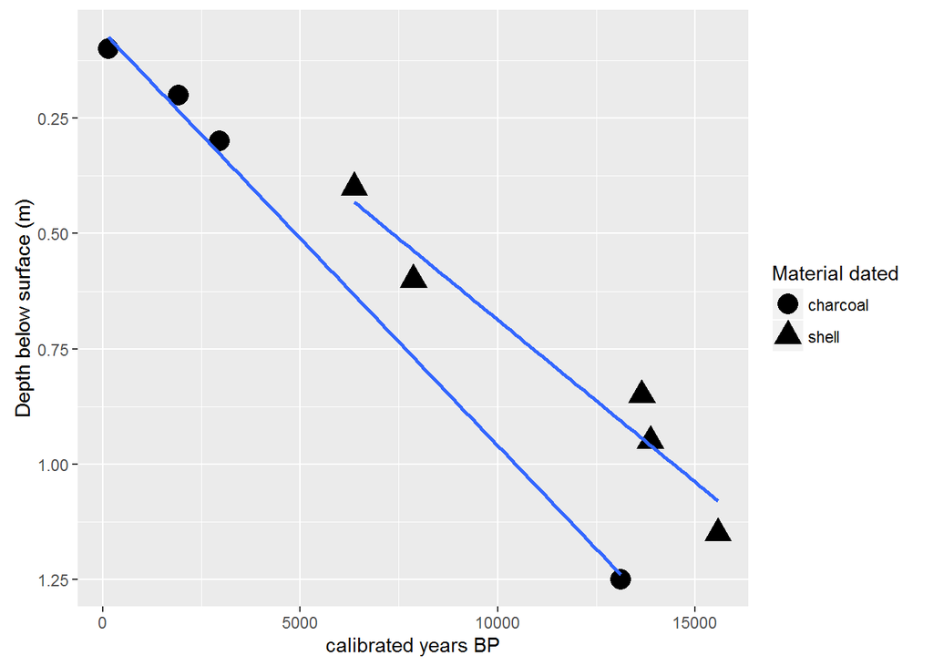

Figure 1: Depth-age plot of calibrated radiocarbon dates from Khao Toh Chong

The depth-age relationship for the dated samples is strongly linear, suggesting a constant rate of sediment accumulation. Although there is nearly a meter between the lowest and second lowest charcoal samples, the linear tendency of the shell samples that span this gap suggest that the accumulation of sediment at the site has been constant through the Holocene.

### Geoarchaeology

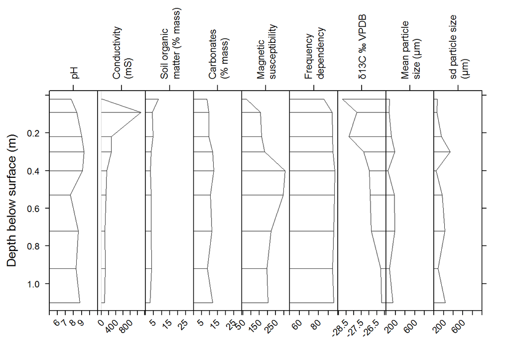

Figure 2: Summary of bulk sediment analysis of samples from Khao Toh Chong

Analysis of sediments collected from the 2011 Khao Toh Chong excavations show a relatively constant depositional environment. The deposit is mostly sandy silt with occassional additions of coarser sands and gravels (for example in context A-4, 0.3 m below surface). Slight fluctuations in particle size distribution and carbonate percentage suggest minor variations in contributions from alluvial, fluvial and colluvial inputs (including limestone eroding from the karst tower). Overall the picture is of relatively constant and uninterrupted deposition.

#### Chemical analyses and magnetic susceptibility

The results of the basic chemical, magnetic susceptibility and particle size analyses are depicted in Figure 2. pH values at KTC are strongly alkaline throughout, with a shift occurring from pH 9.1 to 7.6 between contexts A-5 and A-6 (0.4-0.53 m below surface). Electrical conductivity (as a proxy for soluble minerals) and soil organic matter decline sharply below the surface, probably due to natural decay of organics. Soil carbonates are steady between 8% and 12% throughout. Low frequency magnetic susceptibility peaks at 308 in context A-5 (0.40 m below surface), indicating an enrichment of magnetic minerals in the deposit. This context also has the highest proportion of carbonates (12%), which would reduce magnetic susceptibility, so the change in A-5 is not a simple dilution of magnetic minerals by diagmatic minerals. Frequency dependency varys little, suggesting little change in the size of magnetic particles.

#### X-ray Diffraction

| Context | Quartz | Calcite | Kaolinite | Periclase |
| --- | --- | --- | --- | --- |
| B1 | 79.6 | 12.6 | 0.0 | 7.9 |
| A2 | 66.1 | 11.1 | 19.9 | 2.9 |
| A3 | 64.3 | 12.2 | 19.6 | 4.0 |
| A4 | 89.5 | 7.8 | 0.0 | 2.7 |
| A5 | 92.3 | 7.7 | 0.0 | 0.0 |
| A6 | 68.9 | 9.5 | 19.0 | 2.6 |
| A7U | 80.5 | 19.5 | 0.0 | 0.0 |
| A8 | 81.4 | 12.9 | 0.0 | 5.7 |
| A7L | 87.2 | 10.3 | 0.0 | 2.5 |

Table 2: Summary of X-ray diffraction data from Khao Toh Chong

The XRD analysis showed quartz and calcite present in all samples. Kaolinite was identified in samples in A-2, A-3, and A-6, suggesting a greater contribution of more intensely weathered sediment during the formation of those deposits. An alternative possibility is that the Kaolinite derives from ceramics found in those contexts. The proportions of Calcite in each sample support the loss on ignition results for carbonates, showing low varition throughout the sequence. Small amounts of Periclase were observed, indicating metamorphosis of the local limestone.

#### Inductively coupled plasma-atomic emission spectrometry

|  | Ca | Fe | K | Mg | Mn | Na | Sr | Ti | Zn |
| --- | --- | --- | --- | --- | --- | --- | --- | --- | --- |
| KTC-B-1 | 5.68 | 5.19 | 4.29 | 5.01 | 4.24 | 4.45 | 2.30 | 2.89 | 2.94 |
| KTC-A-2-DH | 5.25 | 4.94 | 3.88 | 4.80 | 3.90 | 3.94 | 1.98 | 2.82 | 2.61 |
| KTC-A-3-DH | 5.17 | 4.85 | 3.80 | 4.70 | 3.81 | 3.71 | 1.94 | 2.71 | 2.49 |
| KTC-A-4 | 5.64 | 5.18 | 4.17 | 5.00 | 4.14 | 3.91 | 2.40 | 3.14 | 2.85 |
| KTC-A-5 | 5.48 | 5.04 | 3.90 | 4.86 | 3.95 | 3.61 | 2.21 | 2.87 | 2.68 |
| KTC-A-6 | 5.46 | 5.10 | 3.88 | 4.91 | 4.01 | 3.49 | 2.19 | 2.77 | 2.77 |
| KTC-A-7-up | 5.61 | 5.26 | 4.23 | 5.09 | 4.15 | 3.56 | 2.47 | 3.18 | 2.93 |
| KTC-A-8 | 5.44 | 5.15 | 3.99 | 4.77 | 4.05 | 3.27 | 2.27 | 2.96 | 2.68 |
| KTC-A-7lo | 5.57 | 5.23 | 4.14 | 4.86 | 4.13 | 3.35 | 2.49 | 3.07 | 2.82 |

Table 3: Elemental concentration by ICP-AES, all measurements are in ppm

|  | Ca | Fe | K | Mg | Mn | Na | Sr | Ti | Zn |
| --- | --- | --- | --- | --- | --- | --- | --- | --- | --- |
| Ca | 1.00 | 0.92 | 0.89 | 0.86 | 0.95 | 0.20 | 0.89 | 0.71 | 0.95 |
| Fe | 0.92 | 1.00 | 0.86 | 0.76 | 0.94 | -0.09 | 0.97 | 0.82 | 0.91 |
| K | 0.89 | 0.86 | 1.00 | 0.82 | 0.95 | 0.35 | 0.82 | 0.76 | 0.92 |
| Mg | 0.86 | 0.76 | 0.82 | 1.00 | 0.81 | 0.34 | 0.71 | 0.66 | 0.93 |
| Mn | 0.95 | 0.94 | 0.95 | 0.81 | 1.00 | 0.24 | 0.86 | 0.71 | 0.96 |
| Na | 0.20 | -0.09 | 0.35 | 0.34 | 0.24 | 1.00 | -0.19 | -0.16 | 0.25 |
| Sr | 0.89 | 0.97 | 0.82 | 0.71 | 0.86 | -0.19 | 1.00 | 0.88 | 0.85 |
| Ti | 0.71 | 0.82 | 0.76 | 0.66 | 0.71 | -0.16 | 0.88 | 1.00 | 0.70 |
| Zn | 0.95 | 0.91 | 0.92 | 0.93 | 0.96 | 0.25 | 0.85 | 0.70 | 1.00 |

Table 4: Correlation matrix of elements analysed by ICP-AES

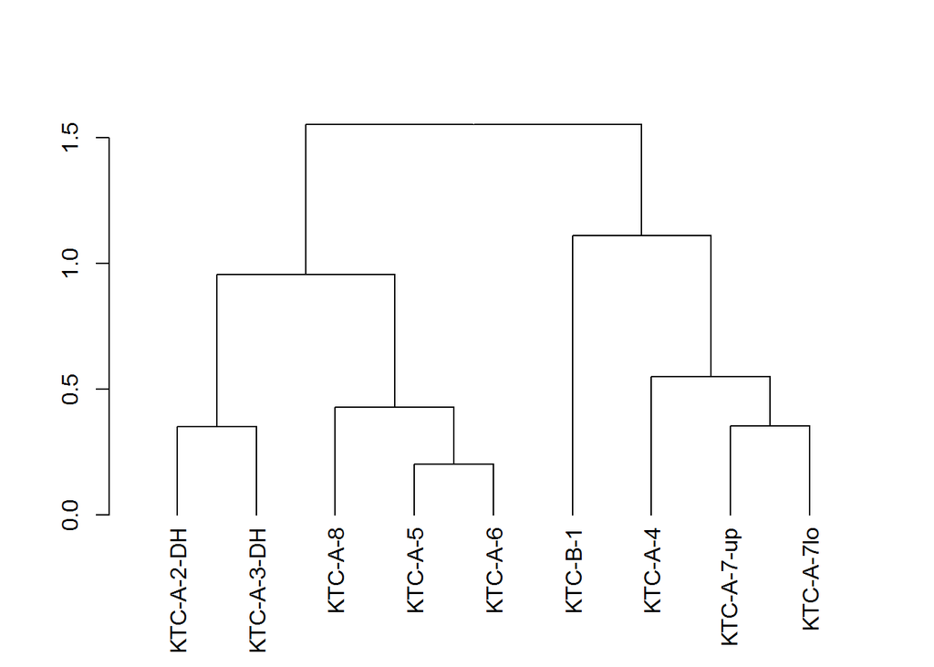

Figure 3: Dendrogram of samples based on ICP-AES results

### Archaeology

| Context | Lithic count (n) | Lithic mass (g) | Ceramic count (n) | Ceramic mass (g) |
| --- | --- | --- | --- | --- |
| 1 | 2 | 18.7 | 99 | 176.2 |
| 2 | NA | NA | 1 | 0.9 |
| 3 | NA | NA | 194 | 417.9 |
| 4 | 20 | 73.6 | 162 | 383.7 |
| 5 | 11 | 19.4 | 42 | 67.0 |
| 6 | 2 | 2.7 | 34 | 111.3 |
| 7H | 2 | 6.3 | 24 | 38.1 |
| 8 | 3 | 3.5 | NA | NA |
| 7L | 8 | 57.8 | 2 | 42.2 |

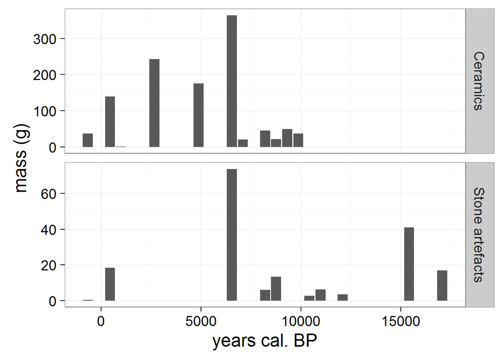

### Faunal assemblage

The values for species richness per context, of the mammalian, reptilian, and piscean taxa appears to be driven primarily by the presence or absence of carapace elements belonging to the Order Testudines, likely representing species of the turtle Family Trionychidae and Emydidae, based upon comparable faunal analyses at Lang Rongrien Rockshelter (Mudar and Anderson, 2007). Identification of abundant *Varanus* sp., and a moderate representation of *Macaca* sp., occurred in abundance with Testundines elements. Overall the presence of vertebrate remains, in comparison with invertebrate remains, was low at the rockshelter. Artiodactyl remains are notably restricted to the terminal Pleistocene and early Holocene deposits.

## Discussion

### Faunal assemblage

KTC rockshelter has a relatively undisturbed record of mammalian, reptilian, piscean, and molluscan assemblages present in relatively intact deposits. The invertebrate record at the rockshelter provides a valuable description of molluscan taxa and subsistence patterns during the ‘missing millenia’. *Neoradina prasongi* molluscs were abundant during the late-Pleistocene, but much less frequent during the mid and late Holocene.

At Lang Rongrien, the abundant Testudines elements through time provided evidence of Southeast Asian turtle and tortoise exploitation occurred at the rockshelter (Mudar and Anderson, 2007). This record also appears at KTC with the presence of abundant Testudines specimens throughout the late-Pleistocene and Holocene deposits. However, this pattern has not been found elsewhere near KTC in southern peninsular Thailand. For example, both Moh Khiew Cave and Sakai Cave had very low abundances of Testudines remains during the late-Pleistocene and Holocene (Pookajorn, 1996). Generally, Testudines elements were only identified by presence or absence at these sites. Since Lang Rongrien and KTC both provide evidence of turtle and tortoise exploitation, this represents a supports the recognition of fresh-water stream foraging pattern. It also suggests that fresh-water stream habitats were abundant during the late-Pleistocene and early Holocene, in the Krabi region. Furthermore, previously identified shifts in monsoon seasonality, and intensity, during this time suggests that precipitation may have increased during the early Holocene in Peninsular Thailand (Marwick and Gagan, 2011), matching the faunal record at KTC .

The declining exploitation of freshwater *N. prasongi* molluscs into the Holocene, reaching a minimum at 6000 cal BP may reflect the shift from freshwater to mangrove swamp habitats in this region, or a shift in the foraging dynamics of prehistoric groups (Shoocongdej, 2000 and 2010). The timing of the lowest amount of shells in the deposit coincides with the peak sea levels observed by Sinsakul (1992). Rising sea-levels throughout the Holocene would have shifted mangrove environments closer to the rockshelter over time, which may have influenced the abundance and distribution of locally available resources and freshwater stream environments (Anderson, 1990; Horten et al., 2005; Tjia, 1996, and Sinsakul, 1992). These initial faunal data from KTC describe a pattern of forager groups utilizing a diverse range of locally available taxa in the tropical rainforest environment, suggesting that foragers at KTC were able to effectively adapt to shifts in local environmental conditions. Additionally, our radiocarbon dates suggest that once intensive harvesting of *N. prasongi* ends during the middle-Holocene, the emergence of rice agriculture and farming in mainland Southeast appears (Barker et al., 2005; Castillo, 2011, White et al., 2004). Thus, declines in mollusk utilization may reflect a pattern of rising sea-levels, favouring the adoption of agriculture during the mid and late-Holocene in peninsular Thailand as a response to these conditions. Shell exploitation picks up again at KTC at 3000 cal BP, coincident with the regressive phase at 3700 to 2700 BP described by Sinsakul (1992).

Our data from KTC not only suggests that a subsistence change occurred at the Pleistocene-Holocene transition, but that foragers utilizing the rockshelter displayed a unique pattern of faunal exploitation not previously seen at archaeological sites in Thailand. As noted above, elsewhere in Thailand, large abundances of shellfish in rockshelter sites tend to date to the middle Holocene when a transition towards a broad-spectrum diet occurs, not during the terminal Pleistocene (Bulbeck 2003). The earlier peak in the molluscan assemblage at KTC suggests that a different pattern of shellfish exploitation occurred here, one that we link to local environmental conditions. This suggests that the diversity of past human subsistence behaviours in this region may have been underestimated and broader diets may have appeared earlier than previously observed.

## References

Vinh, B. (1991). [TRANSITIONS TO AGRICULTURE IN THE EASTERN OLD WORLD] The Da But Culture in the Stone Age of Viet Nam. Bulletin of the Indo-Pacific Prehistory Association, 10, 127-131.